# ryzyko22

```python
import pandas as pd
import numpy as np
import seaborn as sns
from sklearn.metrics import confusion_matrix
```

## zaladowanie danych

```python
from ucimlrepo import fetch_ucirepo

# fetch dataset
polish_companies_bankruptcy = fetch_ucirepo(id=365)

# data (as pandas dataframes)
X = polish_companies_bankruptcy.data.features
y = polish_companies_bankruptcy.data.targets

# metadata
print(polish_companies_bankruptcy.metadata)

# variable information
print(polish_companies_bankruptcy.variables)
```

```
{'uci_id': 365, 'name': 'Polish Companies Bankruptcy', 'repository_url': 'https://archive.ics.uci.edu/dataset/365/polish+companies+bankruptcy+data', 'data_url': 'https://archive.ics.uci.edu/static/public/365/data.csv', 'abstract': 'The dataset is about bankruptcy prediction of Polish companies.The b…
     name     role        type demographic description units missing_values
0    year  Feature     Integer        None        None  None             no
1      A1  Feature  Continuous        None        None  None             no
2      A2  Feature  Continuous        None        None  None             no
3      A3  Feature  Continuous        None        None  None             no
4      A4  Feature  Continuous        None        None  None            yes
..    ...      ...         ...         ...         ...   ...            ...
61    A61  Feature  Continuous        None        None  None            yes
62    A62  Feature  Continuous        None        None  None             no
63    A63  Feature  Continuous        None        None  None            yes
64    A64  Feature  Continuous        None        None  None            yes
65  class   Target     Integer        None        None  None             no

[66 rows x 7 columns]
```

```python
dane = polish_companies_bankruptcy['data']['features']
```

```python
target=polish_companies_bankruptcy['data']['targets']
```

```python
polish_companies_bankruptcy['data']['features']
```

|  | year | A1 | A2 | A3 | A4 | A5 | A6 | A7 | A8 | A9 | ... | A55 | A56 | A57 | A58 | A59 | A60 | A61 | A62 | A63 | A64 |
| --- | --- | --- | --- | --- | --- | --- | --- | --- | --- | --- | --- | --- | --- | --- | --- | --- | --- | --- | --- | --- | --- |
| 0 | 1 | 0.200550 | 0.37951 | 0.396410 | 2.04720 | 32.3510 | 0.38825 | 0.249760 | 1.33050 | 1.13890 | ... | 348690.00 | 0.121960 | 0.397180 | 0.87804 | 0.001924 | 8.4160 | 5.1372 | 82.658 | 4.4158 | 7.42770 |
| 1 | 1 | 0.209120 | 0.49988 | 0.472250 | 1.94470 | 14.7860 | 0.00000 | 0.258340 | 0.99601 | 1.69960 | ... | 2304.60 | 0.121300 | 0.420020 | 0.85300 | 0.000000 | 4.1486 | 3.2732 | 107.350 | 3.4000 | 60.98700 |
| 2 | 1 | 0.248660 | 0.69592 | 0.267130 | 1.55480 | -1.1523 | 0.00000 | 0.309060 | 0.43695 | 1.30900 | ... | 6332.70 | 0.241140 | 0.817740 | 0.76599 | 0.694840 | 4.9909 | 3.9510 | 134.270 | 2.7185 | 5.20780 |
| 3 | 1 | 0.081483 | 0.30734 | 0.458790 | 2.49280 | 51.9520 | 0.14988 | 0.092704 | 1.86610 | 1.05710 | ... | 20545.00 | 0.054015 | 0.142070 | 0.94598 | 0.000000 | 4.5746 | 3.6147 | 86.435 | 4.2228 | 5.54970 |
| 4 | 1 | 0.187320 | 0.61323 | 0.229600 | 1.40630 | -7.3128 | 0.18732 | 0.187320 | 0.63070 | 1.15590 | ... | 3186.60 | 0.134850 | 0.484310 | 0.86515 | 0.124440 | 6.3985 | 4.3158 | 127.210 | 2.8692 | 7.89800 |
| ... | ... | ... | ... | ... | ... | ... | ... | ... | ... | ... | ... | ... | ... | ... | ... | ... | ... | ... | ... | ... | ... |
| 43400 | 5 | 0.012898 | 0.70621 | 0.038857 | 1.17220 | -18.9070 | 0.00000 | 0.013981 | 0.41600 | 1.67680 | ... | 3599.10 | 0.020169 | 0.043904 | 1.01220 | 1.259400 | 13.4720 | 12.4320 | 49.117 | 7.4313 | 2.27990 |
| 43401 | 5 | -0.578050 | 0.96702 | -0.800850 | 0.16576 | -67.3650 | -0.57805 | -0.578050 | -0.40334 | 0.93979 | ... | -9242.10 | -0.064073 | 1.482000 | 1.06410 | -0.018084 | 110.7200 | 44.7590 | 81.220 | 4.4940 | 5.13050 |
| 43402 | 5 | -0.179050 | 1.25530 | -0.275990 | 0.74554 | -120.4400 | -0.17905 | -0.154930 | -0.26018 | 1.17490 | ... | -58253.00 | 0.148880 | 0.548240 | 0.85112 | -0.522430 | 9.8526 | 3.4892 | 207.870 | 1.7559 | 9.95270 |
| 43403 | 5 | -0.108860 | 0.74394 | 0.015449 | 1.08780 | -17.0030 | -0.10886 | -0.109180 | 0.12531 | 0.84516 | ... | 1107.50 | -0.183200 | -1.167700 | 1.18320 | 6.092400 | 13.8860 | 6.0769 | 83.122 | 4.3911 | 0.95575 |
| 43404 | 5 | -0.105370 | 0.53629 | -0.045578 | 0.91478 | -56.0680 | -0.10537 | -0.109940 | 0.86460 | 0.95040 | ... | -425.13 | -0.052186 | -0.227250 | 1.05220 | 0.003196 | 7.7332 | 4.7174 | 136.850 | 2.6672 | 2.79270 |

43405 rows × 65 columns

## model altmana

```python
dane['Z_Wartosc_altmana'] = 1.2*dane['A3'] + 1.4*dane['A6'] + 3.3*dane['A7']+0.6*dane['A8']+0.88*dane['A9']
```

```python
dane['true_variable'] =target
```

```python
dane['wartosc'] =  np.where(dane['Z_Wartosc_altmana']<2.68,1,0) # zeby nie miec szarej strefy 2.68 poniżej bankructwo
```

```python
wybrane_do_mc = dane[dane['year']==5]
```

```python
probkowane = pd.concat([
    wybrane_do_mc[wybrane_do_mc["true_variable"] == 1].sample(100, ), # sammplowanie tak zebysmy mieli razem 200 obserwacji, 100 z bankructwem i 100 bez
    wybrane_do_mc[wybrane_do_mc["true_variable"] == 0].sample(100, )
])
```

```python
confusion_matrix(probkowane['true_variable'],probkowane['wartosc'])
```

```
array([[40, 60],
       [24, 76]], dtype=int64)
```

```python
from sklearn.metrics import accuracy_score

print(accuracy_score(probkowane['true_variable'], probkowane['wartosc']))
```

```
0.58
```

- Nie jest skuteczym narzędziem, ponieważ ma skuteczność 58%, troche jest lepszy niż coin flip.
- Wagi do każdej zmiennej używane do modelu altmana nie były liczone na podstawie polskich firm, co również się przczynia na taki wynik.
- Dodatkowo Skrócie Altman wziął firmy głównie przemysłowe, polskie firmy są w większości usługowe + gospodarka stanów w latach 60 XX wieku i jej rachunkowości jest na pewno diametralnie inna niż polska gospodarka i jej standardy rachunkowości XXI wieku.

## model altmana bootstrap

```python
wyniki_accuracy = []

for d in range(100000):
    probkowane = pd.concat([
                    wybrane_do_mc[wybrane_do_mc["true_variable"] == 1].sample(100,replace=True ), # sammplowanie tak zebysmy mieli razem 200 obserwacji, 100 z bankructwem i 100 bez
                    wybrane_do_mc[wybrane_do_mc["true_variable"] == 0].sample(100, replace=True)
                ])

    wyniki_accuracy.append(accuracy_score(probkowane['true_variable'], probkowane['wartosc']))
```

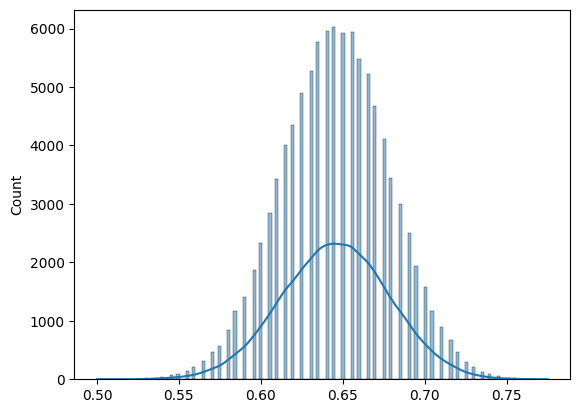

```python
sns.histplot(wyniki_accuracy,kde=True)
```

```python
print(np.mean(wyniki_accuracy))
```

```
0.6455259499999999
```

```python
print(np.quantile(wyniki_accuracy,q=[0.025,0.975]))
```

```
[0.58 0.71]
```

- w metodzie boostrap średni wynik accuracy jest średnio nico lepszy niż w pojedyńczym oszacownaiu, jednakże nie jest to wynik zbliżony do bardzo dobrego (tzn około 90%), jest on przeciętny, dodatkowo 95% predział ufności pokazuje ze accuracy modelu jest nie większa niż 71%, co ponownie jest wynikiem conajwyżej srednim średnim.
- następnym krokiem będzie porównanie modelu regresji logistycznej i lasu losowego do predykcji z modelem altmana

## regresja logistyczna

```python
from statsmodels.formula.api import logit
from sklearn.model_selection import train_test_split

train, test = train_test_split(probkowane, test_size=0.2, random_state=42,stratify=probkowane['true_variable'])



model = logit('true_variable ~ A3 + A6 + A7 + A8 + A9', data=train).fit()
```

```
Optimization terminated successfully.
         Current function value: 0.552901
         Iterations 8
```

```python
print(model.summary())
```

```
                           Logit Regression Results
==============================================================================
Dep. Variable:          true_variable   No. Observations:                  158
Model:                          Logit   Df Residuals:                      152
Method:                           MLE   Df Model:                            5
Date:                śr., 08 kwi 2026   Pseudo R-squ.:                  0.2295
Time:                        20:31:42   Log-Likelihood:                -84.385
converged:                       True   LL-Null:                       -109.52
Covariance Type:            nonrobust   LLR p-value:                 1.223e-09
==============================================================================
                 coef    std err          z      P>|z|      [0.025      0.975]
------------------------------------------------------------------------------
Intercept     -0.5489      0.319     -1.721      0.085      -1.174       0.076
A3            -0.6588      0.615     -1.072      0.284      -1.864       0.546
A6            -1.3070      0.454     -2.877      0.004      -2.197      -0.417
A7            -3.8230      1.154     -3.314      0.001      -6.084      -1.562
A8             0.0122      0.012      1.032      0.302      -0.011       0.035
A9             0.2988      0.148      2.015      0.044       0.008       0.589
==============================================================================
```

## conf matrix na danych treningowych i testowych

```python
print("dane treningowe ")
print(accuracy_score(train["true_variable"], (model.predict(train) >= 0.5).astype(int)))
print()
print(confusion_matrix(train["true_variable"], (model.predict(train) >= 0.5).astype(int)))
```

```
dane treningowe
0.75

[[67 13]
 [27 53]]
```

```python
test['y_prob'] = model.predict(test)
test['y_pred'] = (test['y_prob'] > 0.5).astype(int)
```

```python
print("dane testowe")
print(accuracy_score(test['true_variable'], test['y_pred']))
print()
print(confusion_matrix(test['true_variable'], test['y_pred']))
```

```
dane testowe
0.7

[[16  4]
 [ 8 12]]
```

- dla pojedyńczej próbki widać róznice regresji logistycznej, jest lepsza na danych testowych o 12% niż model altmana trenowana na tych samych zmiennych

## boostrap logistyczna

```python
from sklearn.model_selection import StratifiedKFold
from sklearn.linear_model import LogisticRegression
from sklearn.metrics import accuracy_score

wyniki_accuracy_cv_train = []

wyniki_accuracy_cv_val = []

cv = StratifiedKFold(n_splits=5, shuffle=True, random_state=42)

kolumny = ["A3", "A6", "A7", "A8", "A9"]

for d in range(1000):
    probkowane = pd.concat([

        wybrane_do_mc[wybrane_do_mc["true_variable"] == 1].sample(100, replace=True),
        wybrane_do_mc[wybrane_do_mc["true_variable"] == 0].sample(100, replace=True)
    ])

    probkowane = probkowane.dropna(subset=kolumny + ["true_variable"]) # usuwanie nan

    X = probkowane[kolumny]
    y = probkowane["true_variable"]

    fold_train_scores = []
    fold_val_scores = []

    for train_idx, val_idx in cv.split(X, y):

        X_train = probkowane.iloc[train_idx][kolumny]
        y_train = probkowane.iloc[train_idx]["true_variable"]

        X_val = probkowane.iloc[val_idx][kolumny]
        y_val = probkowane.iloc[val_idx]["true_variable"]

        model = LogisticRegression(max_iter=1000)
        model.fit(X_train, y_train)

        fold_train_scores.append(accuracy_score(y_train, model.predict(X_train))) # fit na treningowe dane
        fold_val_scores.append(accuracy_score(y_val, model.predict(X_val))) # predykcja na te niewidziane wczesniej (walidacja)

    wyniki_accuracy_cv_train.append(np.mean(fold_train_scores))
    wyniki_accuracy_cv_val.append(np.mean(fold_val_scores))
```

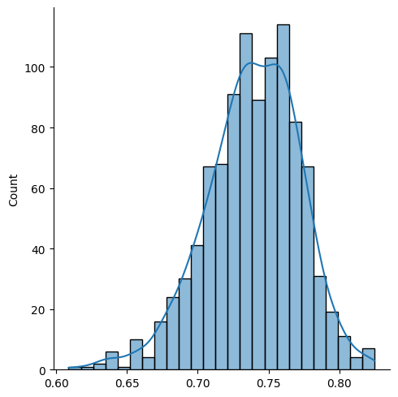

```python
sns.displot(wyniki_accuracy_cv_train, kde=True) # wynik na dopasowanie do danych treningowych
```

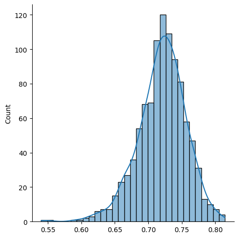

```python
sns.displot(wyniki_accuracy_cv_val, kde=True)
```

```python
print(np.mean(wyniki_accuracy_cv_val))
print(np.quantile(wyniki_accuracy_cv_val,q=[0.025,0.975]))
```

```
0.7209615249662618
[0.641625 0.785   ]
```

- Wyniki rozkładów ( na oko bez używania testów staystycznych np Mann-Whitney) , regresja logistyczna otrzymała lepsze wyniki na tych samych zmiennych niż model altmana
- Dodatkowo przedizały ufności się przesunęły jak i średnia wartość

# Random forest

- Teraz przetestujemy RF i spróbujemy znaleźć inne zmienne niż te które wskazał Altman

```python
from sklearn.ensemble import RandomForestClassifier
from sklearn.impute import SimpleImputer

probkowane = pd.concat([
    wybrane_do_mc[wybrane_do_mc["true_variable"] == 1].sample(100, replace=True),  # samplowanie tak, żeby mieć razem 200 obserwacji: 100 z bankructwem i 100 bez
    wybrane_do_mc[wybrane_do_mc["true_variable"] == 0].sample(100, replace=True)
])

X = probkowane[[col for col in probkowane.columns if col != "true_variable"]]
y = probkowane["true_variable"]

X_train, X_test, y_train, y_test = train_test_split( X, y, test_size=0.2, random_state=42, stratify=y)

# imputowanie medianą Nanow
imputer = SimpleImputer(strategy="median") # mediana jest imputowana

X_train_imp = pd.DataFrame( imputer.fit_transform(X_train), columns=cechy, index=X_train.index)

X_test_imp = pd.DataFrame( imputer.transform(X_test), columns=cechy, index=X_test.index)

rf_model = RandomForestClassifier( n_estimators=300, random_state=42,max_depth=3,min_samples_split=5,min_samples_leaf=2)

rf_model.fit(X_train_imp, y_train)

y_train_pred = rf_model.predict(X_train_imp)
y_test_pred = rf_model.predict(X_test_imp)
```

```python
print("Accuracy train:")
print(accuracy_score(y_train, y_train_pred))
print("Accuracy test:")
print(accuracy_score(y_test, y_test_pred))
```

```
Accuracy train:
0.86875
Accuracy test:
0.85
```

```python
print(confusion_matrix(y_test, y_test_pred))
```

```
[[18  2]
 [ 4 16]]
```

```python
feature_importance = pd.DataFrame({"zmienna": cechy,"importance": rf_model.feature_importances_}).sort_values("importance", ascending=False)

display(feature_importance)
```

|  | zmienna | importance |
| --- | --- | --- |
| 16 | A16 | 0.063647 |
| 35 | A35 | 0.054308 |
| 13 | A13 | 0.052398 |
| 26 | A26 | 0.043691 |
| 14 | A14 | 0.043039 |
| ... | ... | ... |
| 49 | A49 | 0.003246 |
| 63 | A63 | 0.002818 |
| 37 | A37 | 0.001530 |
| 0 | year | 0.000000 |
| 66 | wartosc | 0.000000 |

67 rows × 2 columns